# Lista 1

Piotr Wojcik

10/12/2021

## Zadanie 1

W poniższym zadaniu wygenerujemy $\small 100$ wektorów losowych z rozkładu *dwuwymiarowego normalnego* $\small N(0,I)$. Następnie zaznaczymy je na płaszczyźynie.

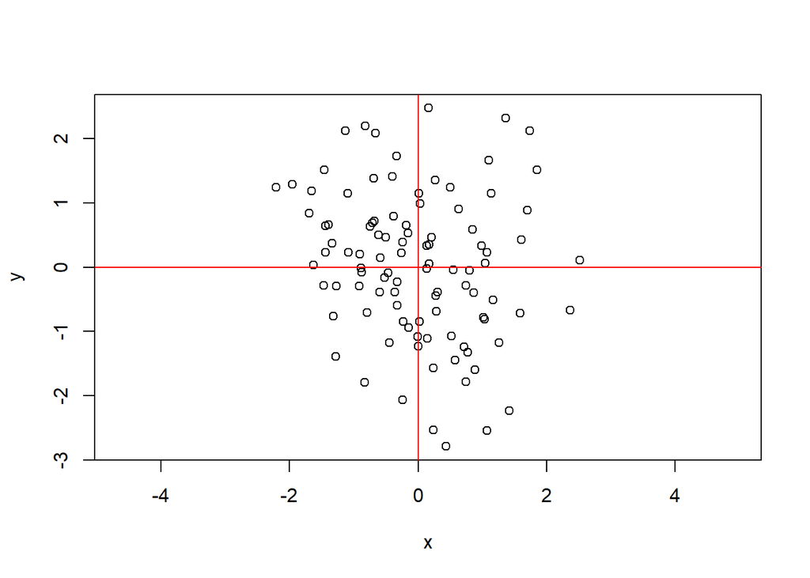

```r
cloud1 <- sapply(1:100, function(x) matrix(rnorm(2)))
plot(cloud1[1, ], cloud1[2, ], asp = TRUE, xlab = "x", ylab = "y")
abline(h = 0, v = 0, col = "red")
```

Zauważmy, że wszystkie punkty, są skupione w punkcie $\small (0,0)$, czego można się spodziewać, ponieważ średnia naszego rozkładu wynosi $\small \mu = \begin{pmatrix} 0 \\ 0 \end{pmatrix}.$ Są one chaotycznie rozproszone, bez widocznej zależności, co sugeruje, że dane są nieskorelowane.

## Zadanie 2

W poniższym zadaniu przekształcimy chmurę punktów wygenerowaną w poprzednim zadaniu, w taki sposób aby uzyskać chmurę z rozkładu $\small N(\mu, \Sigma)$, gdzie:

- $\small \mu = \begin{pmatrix} 4 \\ 2 \end{pmatrix}, \hspace{10px} \Sigma = \begin{pmatrix} 1 & 0.9\\ 0.9 & 1 \end{pmatrix},$
- $\small \mu = \begin{pmatrix} 4 \\ 2 \end{pmatrix}, \hspace{10px} \Sigma = \begin{pmatrix} 1 & -0.9\\ -0.9 & 1 \end{pmatrix},$
- $\small \mu = \begin{pmatrix} 4 \\ 2 \end{pmatrix}, \hspace{10px} \Sigma = \begin{pmatrix} 9 & 0\\ 0 & 1 \end{pmatrix}.$

Obliczenia zaczniemy od napisania algorytmu na *Postać Choleskiego*:

```r
xy <- function(x, y, n = 2) return(x + (y - 1) * n)

seq_xy <- function(x, y, n = 2) {
    seq <- c()
    for (i in 1:y) {
        if (i != y) {
            seq <- c(seq, xy(x, i, n))
        }
    }
    return(seq)
}

choll <- function(A) {
    n <- dim(A)[1]
    X <- matrix(0, nrow = n, ncol = n)
    for (i in 1:n) {
        for (j in 1:i) {
            if (i == j) {
                X[i, j] <- sqrt(A[i, j] - sum(X[seq_xy(i, j, n)]^2))
            } else {
                X[i, j] <- (A[i, j] - sum(X[seq_xy(i, j, n)] * X[seq_xy(j, j, n)]))/(X[j,
                  j])
            }
        }
    }

    return(X)
}
```

Teraz wyznaczymy chmury punktów z nowych rozkładów:

```r
mu <- c(4, 2)
Sigma1 <- matrix(c(1, 0.9, 0.9, 1), nrow = 2, ncol = 2)
Sigma2 <- matrix(c(1, -0.9, -0.9, 1), nrow = 2, ncol = 2)
Sigma3 <- matrix(c(9, 0, 0, 1), nrow = 2, ncol = 2)
Lin_transform <- function(x, mu, Sigma) {
    A <- choll(Sigma)
    return(A %*% x + mu)
}
new_norm1 <- Lin_transform(cloud1, mu, Sigma1)
new_norm2 <- Lin_transform(cloud1, mu, Sigma2)
new_norm3 <- Lin_transform(cloud1, mu, Sigma3)
```

Na zakończenie zaznaczymy na płaszczyźnie powyższe 3 chmury punktów:

#### $\small 1) \quad \mu = \begin{pmatrix} 4 \\ 2 \end{pmatrix}, \hspace{10px} \Sigma = \begin{pmatrix} 1 & 0.9\\ 0.9 & 1 \end{pmatrix}$:

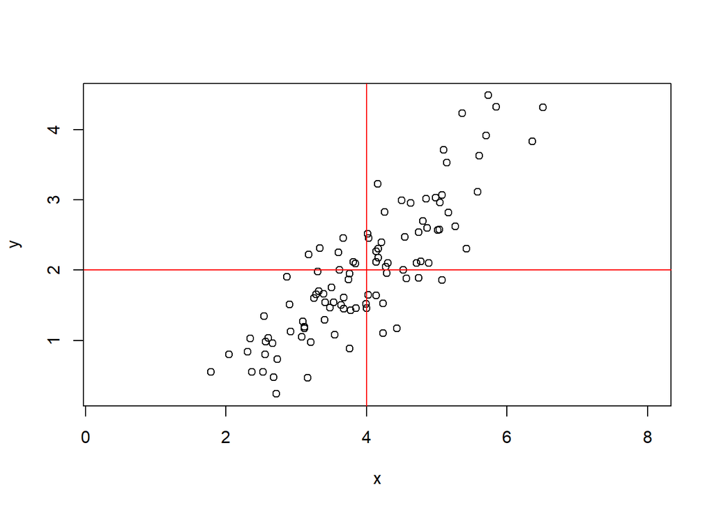

```r
plot(new_norm1[1, ], new_norm1[2, ], asp = TRUE, xlab = "x", ylab = "y")
abline(h = 2, v = 4, col = "red")
```

Na powyższym wykresie możemy zaobserwować, że punkty skupiają się wokół średniej oraz że układają się w prostą, która sugeruje, że zmienne z tego rozkładu są skorelowane.

#### $\small 2) \quad \mu = \begin{pmatrix} 4 \\ 2 \end{pmatrix}, \hspace{10px} \Sigma = \begin{pmatrix} 1 & -0.9\\ -0.9 & 1 \end{pmatrix}$:

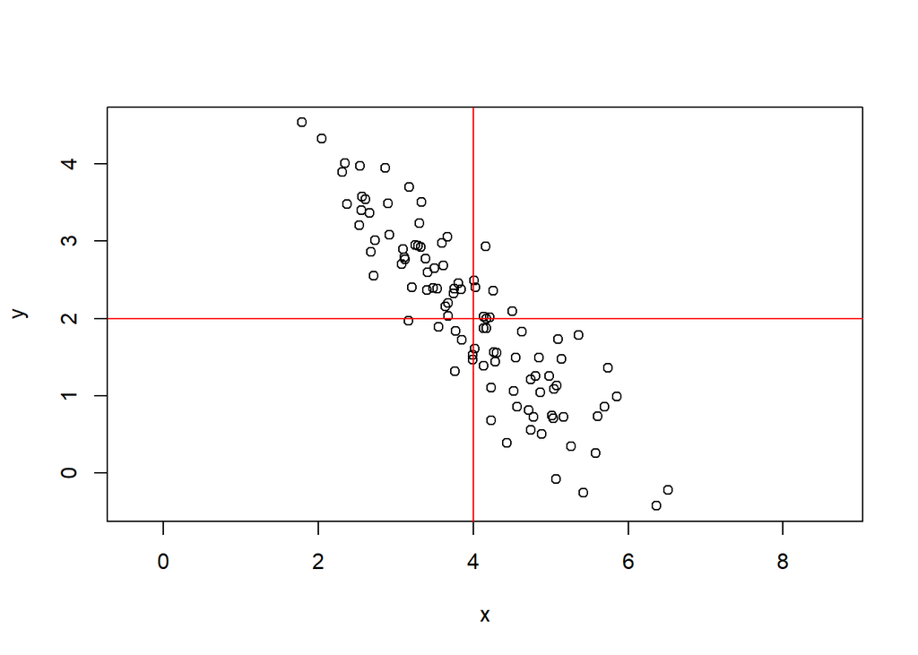

```r
plot(new_norm2[1, ], new_norm2[2, ], asp = TRUE, xlab = "x", ylab = "y")
abline(h = 2, v = 4, col = "red")
```

Na powyższym wykresie możemy zaobserwować, że punkty skupiają się wokół średniej oraz że układają się w prostą, która sugeruje, że zmienne z tego rozkładu są skorelowane.

#### $\small 3) \quad \mu = \begin{pmatrix} 4 \\ 2 \end{pmatrix}, \hspace{10px} \Sigma = \begin{pmatrix} 9 & 0\\ 0 & 1 \end{pmatrix}$:

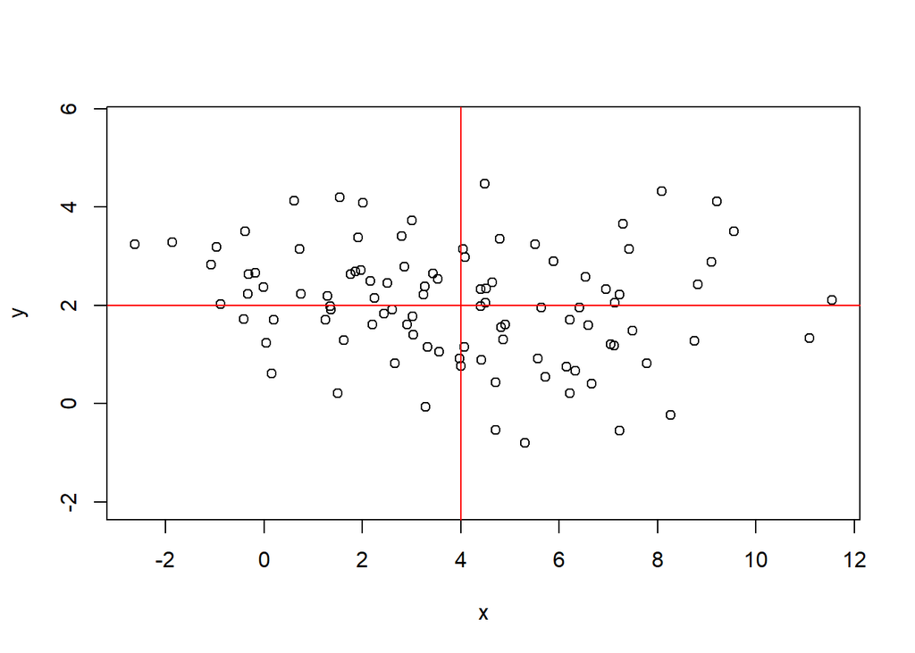

```r
plot(new_norm3[1, ], new_norm3[2, ], asp = TRUE, xlab = "x", ylab = "y")
abline(h = 2, v = 4, col = "red")
```

Na powyższym wykresie już ciężko jednoznacznie zaobserwować wokół czego skupiają się punkty, wynika to z dużej wariancji. Punkty też nie wydają się układać w żadną prostą, przez co można wnioskować, że są nieskorelowane.

## Zadanie 3

W poniższym zadaniu wygenerujemy wielowymiarowy rozkład normalny $\small N(0,\Sigma)$, gdzie $\small \Sigma[i,i] = 1$, oraz $\small \Sigma[i,j] = 0.9$, dla $\small i \neq j$.

```r
matrixSN <- matrix(rnorm(20000), nrow = 200, ncol = 100)
Sigma <- matrix(nrow = 100, ncol = 100)
for (i in 1:100) {
    for (j in 1:100) {
        if (i == j)
            Sigma[i, j] <- 1 else Sigma[i, j] <- 0.9
    }
}
X <- matrix(nrow = 200, ncol = 100)
A <- t(choll(Sigma))
X <- matrixSN %*% A
```

Zweryfikujemym nasze wyniki, wyznaczając histogramy: średniej próbkowej; kowariancji między różnymi współrzędnymi; wariancji.

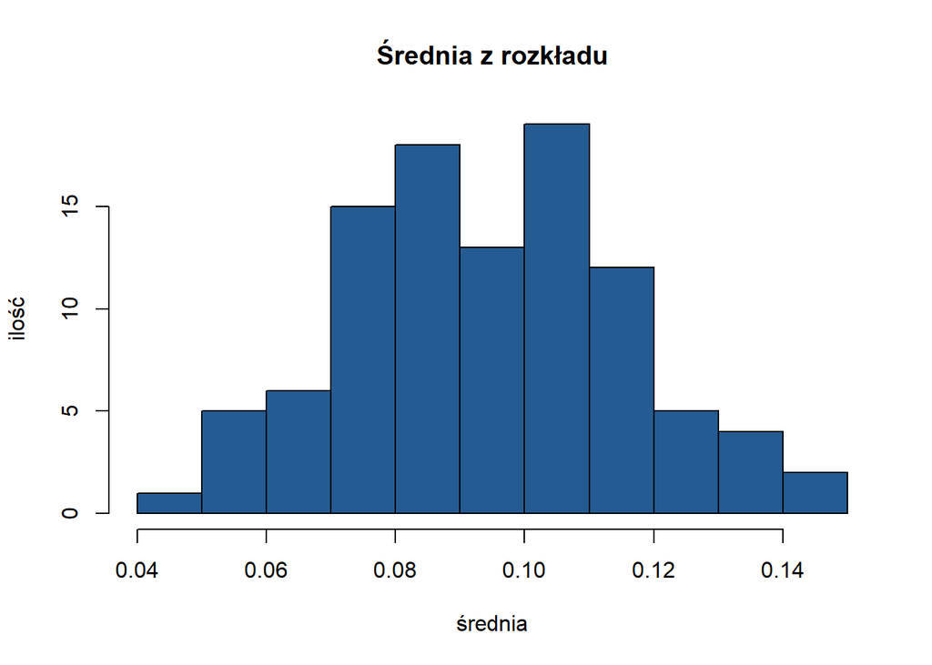

```r
meanX <- sapply(1:100, function(i) mean(X[, i]))
hist(meanX, col = "#245b92", main = "Średnia z rozkładu", xlab = "średnia", ylab = "ilość")
```

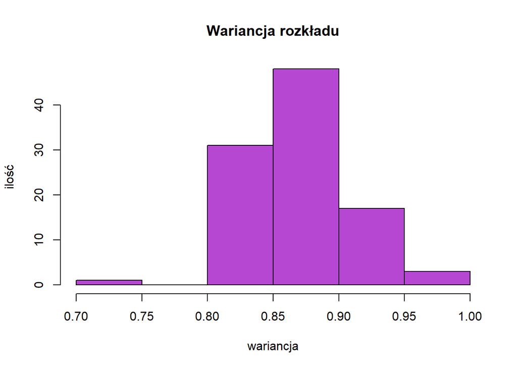

```r
CovX <- cov(X)
DCovX <- CovX[lower.tri(CovX, diag = FALSE)]
hist(diag(CovX), col = "#b647d2", main = "Wariancja rozkładu", xlab = "wariancja",
    ylab = "ilość")
```

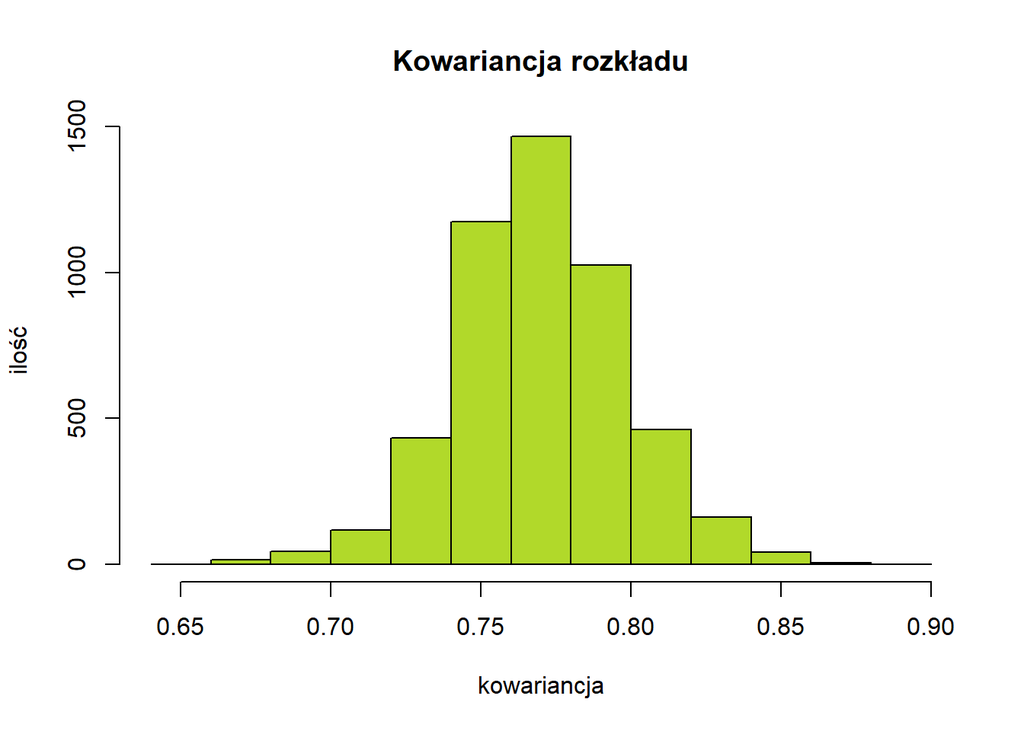

```r
hist(DCovX, col = "#b1d92a", main = "Kowariancja rozkładu", xlab = "kowariancja",
    ylab = "ilość")
```